# Finance_project_income_Vs_expenses

```python
import numpy as np
import pandas as pd
import matplotlib.pyplot as plt
import seaborn as sns
```

```python
df = pd.read_csv(r"C:\Users\anilp\01-python\telangana_financial_data_200k.csv")
df
```

|  | ID | First_Name | Last_Name | Age | Gender | Marital_Status | Education | Profession | City | State | ... | Monthly_Expenses_(INR) | Home_Loan_EMI_(INR) | Car_Loan_EMI_(INR) | Investments_(INR) | Account_Created_On | Last_Transaction_Date | Full_Name | Total_Debt_(INR) | Net_Worth_(INR) | Savings_Rate |
| --- | --- | --- | --- | --- | --- | --- | --- | --- | --- | --- | --- | --- | --- | --- | --- | --- | --- | --- | --- | --- | --- |
| 0 | 1 | Kabir | Singh | 60 | Male | Married | Bachelor's | Pharmacist | Khammam | Telangana | ... | 194872 | 27997 | 1057 | 254526 | 2023-01-14 | 2022-12-26 | Kabir Singh | 1717872 | -1463346 | -1.870570 |
| 1 | 2 | Anaya | Sharma | 50 | Male | Married | High School | Data Scientist | Khammam | Telangana | ... | 184075 | 22344 | 11074 | 278816 | 2015-05-02 | 2022-08-05 | Anaya Sharma | 1739304 | -1460488 | -0.754528 |
| 2 | 3 | Priya | Reddy | 36 | Male | Married | High School | Doctor | Khammam | Telangana | ... | 126857 | 7873 | 132 | 194612 | 2018-06-29 | 2022-10-26 | Priya Reddy | 477132 | -282520 | -1.008266 |
| 3 | 4 | Saanvi | Rao | 64 | Female | Married | Bachelor's | Architect | Mahbubnagar | Telangana | ... | 92807 | 7265 | 1962 | 387221 | 2021-02-04 | 2022-06-16 | Saanvi Rao | 506532 | -119311 | -0.489685 |
| 4 | 5 | Shaurya | Menon | 29 | Female | Married | High School | Teacher | Warangal | Telangana | ... | 125396 | 2894 | 3065 | 534770 | 2021-04-06 | 2023-02-22 | Shaurya Menon | 283980 | 250790 | -3.895445 |
| ... | ... | ... | ... | ... | ... | ... | ... | ... | ... | ... | ... | ... | ... | ... | ... | ... | ... | ... | ... | ... | ... |
| 199995 | 199996 | Ishaan | Naidu | 43 | Male | Divorced | High School | Journalist | Siddipet | Telangana | ... | 125133 | 7124 | 5043 | 152973 | 2017-08-19 | 2022-10-18 | Ishaan Naidu | 608988 | -456015 | -0.881197 |
| 199996 | 199997 | Shaurya | Shah | 61 | Female | Single | Bachelor's | Lawyer | Miryalaguda | Telangana | ... | 187817 | 11375 | 11984 | 209342 | 2015-09-04 | 2022-11-23 | Shaurya Shah | 1113924 | -904582 | -3.291244 |
| 199997 | 199998 | Advait | Mukherjee | 25 | Female | Married | High School | Software Engineer | Ramagundam | Telangana | ... | 139435 | 32387 | 8937 | 92048 | 2020-11-29 | 2022-11-21 | Advait Mukherjee | 2264952 | -2172904 | -2.680165 |
| 199998 | 199999 | Pari | Shah | 41 | Female | Single | Bachelor's | IAS Officer | Miryalaguda | Telangana | ... | 120611 | 7779 | 13991 | 1295419 | 2018-02-01 | 2022-12-30 | Pari Shah | 970416 | 325003 | -0.236009 |
| 199999 | 200000 | Meera | Bose | 37 | Female | Single | High School | Business Owner | Ramagundam | Telangana | ... | 164578 | 10280 | 7050 | 164883 | 2021-08-01 | 2023-08-23 | Meera Bose | 870600 | -705717 | -4.672609 |

200000 rows × 21 columns

```python
df.columns
```

```
Index(['ID', 'First_Name', 'Last_Name', 'Age', 'Gender', 'Marital_Status',
       'Education', 'Profession', 'City', 'State', 'Annual_Income_(INR)',
       'Monthly_Expenses_(INR)', 'Home_Loan_EMI_(INR)', 'Car_Loan_EMI_(INR)',
       'Investments_(INR)', 'Account_Created_On', 'Last_Transaction_Date',
       'Full_Name', 'Total_Debt_(INR)', 'Net_Worth_(INR)', 'Savings_Rate'],
      dtype='object')
```

```python
df.sample(400)
```

|  | ID | First_Name | Last_Name | Age | Gender | Marital_Status | Education | Profession | City | State | ... | Monthly_Expenses_(INR) | Home_Loan_EMI_(INR) | Car_Loan_EMI_(INR) | Investments_(INR) | Account_Created_On | Last_Transaction_Date | Full_Name | Total_Debt_(INR) | Net_Worth_(INR) | Savings_Rate |
| --- | --- | --- | --- | --- | --- | --- | --- | --- | --- | --- | --- | --- | --- | --- | --- | --- | --- | --- | --- | --- | --- |
| 10218 | 10219 | Diya | Reddy | 26 | Male | Married | Bachelor's | Business Owner | Mahbubnagar | Telangana | ... | 174125 | 27283 | 4412 | 577217 | 2020-01-26 | 2023-01-11 | Diya Reddy | 1795812 | -1218595 | -1.246574 |
| 127447 | 127448 | Kavya | Patel | 62 | Male | Single | PhD | IAS Officer | Jagtial | Telangana | ... | 182905 | 14171 | 4778 | 155315 | 2015-04-16 | 2022-07-21 | Kavya Patel | 1022268 | -866953 | -1.895888 |
| 60771 | 60772 | Ishita | Rao | 41 | Male | Married | Master's | Journalist | Nalgonda | Telangana | ... | 76018 | 44672 | 7362 | 38212 | 2022-08-06 | 2022-09-24 | Ishita Rao | 2945352 | -2907140 | 0.102606 |
| 27889 | 27890 | Rahul | Verma | 41 | Female | Married | Master's | Software Engineer | Karimnagar | Telangana | ... | 112900 | 1762 | 5964 | 92930 | 2021-06-08 | 2022-08-30 | Rahul Verma | 320424 | -227494 | -0.934392 |
| 152882 | 152883 | Aditi | Menon | 47 | Female | Married | Master's | Pharmacist | Adilabad | Telangana | ... | 160443 | 7262 | 4316 | 494303 | 2019-04-25 | 2022-03-02 | Aditi Menon | 591096 | -96793 | -1.417679 |
| ... | ... | ... | ... | ... | ... | ... | ... | ... | ... | ... | ... | ... | ... | ... | ... | ... | ... | ... | ... | ... | ... |
| 127474 | 127475 | Zara | Reddy | 41 | Male | Single | Bachelor's | Professor | Nagarkurnool | Telangana | ... | 151983 | 1927 | 4955 | 419460 | 2016-02-06 | 2022-12-25 | Zara Reddy | 294000 | 125460 | -4.307256 |
| 65846 | 65847 | Pari | Gupta | 57 | Female | Married | Bachelor's | Doctor | Khammam | Telangana | ... | 122128 | 13149 | 3611 | 1218041 | 2016-04-14 | 2023-02-26 | Pari Gupta | 918936 | 299105 | -1.107017 |
| 58888 | 58889 | Ayaan | Menon | 47 | Female | Single | Bachelor's | Bank Manager | Nizamabad | Telangana | ... | 100916 | 17056 | 9937 | 135025 | 2020-09-17 | 2022-01-26 | Ayaan Menon | 1381092 | -1246067 | -0.748770 |
| 48473 | 48474 | Myra | Choudhary | 58 | Male | Single | High School | CA | Khammam | Telangana | ... | 133637 | 32477 | 5965 | 97839 | 2018-02-15 | 2022-10-07 | Myra Choudhary | 2163360 | -2065521 | -1.483863 |
| 50119 | 50120 | Anika | Chauhan | 31 | Male | Married | Bachelor's | Professor | Miryalaguda | Telangana | ... | 133949 | 13211 | 35615 | 15163 | 2022-04-11 | 2022-03-03 | Anika Chauhan | 2074800 | -2059637 | -0.639081 |

400 rows × 21 columns

```python
df.reset_index(inplace=True)
```

```python
df.drop(columns=["index"],inplace=True)
```

```python
df
```

[output not shown]

```python
df.isna().sum()
```

```
ID                        0
First_Name                0
Last_Name                 0
Age                       0
Gender                    0
Marital_Status            0
Education                 0
Profession                0
City                      0
State                     0
Annual_Income_(INR)       0
Monthly_Expenses_(INR)    0
Home_Loan_EMI_(INR)       0
Car_Loan_EMI_(INR)        0
Investments_(INR)         0
Account_Created_On        0
Last_Transaction_Date     0
Full_Name                 0
Total_Debt_(INR)          0
Net_Worth_(INR)           0
Savings_Rate              0
dtype: int64
```

```python
df.describe()
```

|  | ID | Age | Annual_Income_(INR) | Monthly_Expenses_(INR) | Home_Loan_EMI_(INR) | Car_Loan_EMI_(INR) | Investments_(INR) | Total_Debt_(INR) | Net_Worth_(INR) | Savings_Rate |
| --- | --- | --- | --- | --- | --- | --- | --- | --- | --- | --- |
| count | 400.000000 | 400.000000 | 4.000000e+02 | 400.000000 | 400.000000 | 400.000000 | 4.000000e+02 | 4.000000e+02 | 4.000000e+02 | 400.000000 |
| mean | 97036.410000 | 43.820000 | 8.224766e+05 | 134468.840000 | 18697.417500 | 7796.792500 | 4.995331e+05 | 1.402530e+06 | -9.029965e+05 | -1.304840 |
| std | 57786.594765 | 12.833915 | 3.588946e+05 | 35393.759073 | 17891.693318 | 8113.619754 | 1.112121e+06 | 1.107951e+06 | 1.492121e+06 | 1.137889 |
| min | 26.000000 | 22.000000 | 3.000000e+05 | 56377.000000 | 40.000000 | 3.000000 | 2.590000e+02 | 5.336400e+04 | -6.971794e+06 | -7.000000 |
| 25% | 45748.250000 | 32.000000 | 5.813472e+05 | 107909.250000 | 5363.250000 | 2102.750000 | 7.253575e+04 | 5.885280e+05 | -1.564672e+06 | -1.866093 |
| 50% | 95112.500000 | 45.000000 | 7.519325e+05 | 131457.500000 | 13236.000000 | 5257.000000 | 2.027630e+05 | 1.096746e+06 | -7.521940e+05 | -1.059696 |
| 75% | 147824.500000 | 56.000000 | 9.812672e+05 | 156515.500000 | 26764.750000 | 10654.750000 | 4.561398e+05 | 1.946454e+06 | -2.590482e+05 | -0.462311 |
| max | 199949.000000 | 64.000000 | 2.535212e+06 | 200000.000000 | 116542.000000 | 59239.000000 | 1.241332e+07 | 7.094796e+06 | 9.771449e+06 | 0.500725 |

```python
df.info()
```

[output not shown]

# **Backstory**

#### * Many individuals struggle with maintaining a healthy balance between their income and expenses, often leading to poor savings habits and financial stress. This project aims to analyze individual financial data to understand spending patterns, savings behavior, and the overall financial health of an individual.

#### * The project compares monthly income with various categories of expenses (such as investments, emi loans, transportation, etc.) to identify trends, gaps, and opportunities for better financial planning. The goal is to provide actionable insights to help individuals track their finances, optimize spending, and increase savings.

## **Business Objectives**

- Analyze how individuals across different income levels manage their expenses.
- Identify patterns of overspending or saving across age groups and genders.
- Identify individuals at risk of financial distress (e.g., high EMI, low income).
- Compare home loan EMI against annual income to determine affordability.

# **The Average salary of people per month**

```python
df["Monthly_Salary_(INR)"]=(df["Annual_Income_(INR)"]/12)
df["Monthly_Salary_(INR)"].mean().round(2)
```

```
68539.71
```

# **The Average monthly_Expenses of people per month**

```python
df["Monthly_Expenses_(INR)"].mean().round(2)
```

```
134468.84
```

# **The Average Annual_investments of people**

```python
df["Investments_(INR)"].mean().round(2)
```

```
499533.07
```

# **What is the distribution of ages in the given dataset ?**

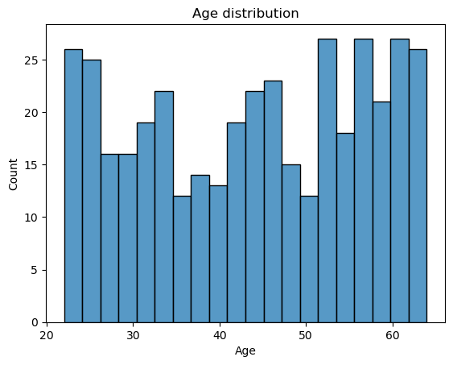

```python
sns.histplot(df,x="Age",bins=20)
plt.title("Age distribution")
plt.show()
```

# Insights

- Most of the individuals are between 20 and 65 years old
- There are high counts around ages 22–26 and 55–63.

# Indivisual Annual income of my sample data

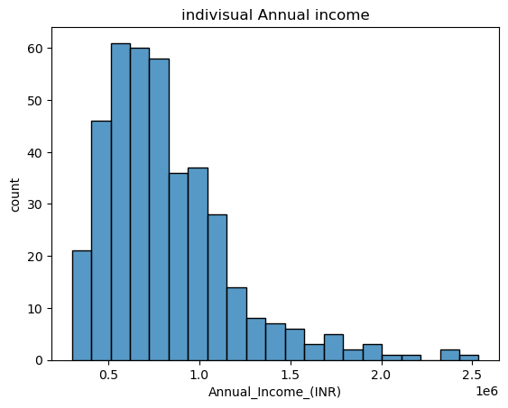

```python
sns.histplot(df["Annual_Income_(INR)"])
plt.title("indivisual Annual income")
plt.xlabel("Annual_Income_(INR)")
plt.ylabel("count")
plt.show()
```

# Insights

# **What does the distribution of savings rates indicate about individuals ?**

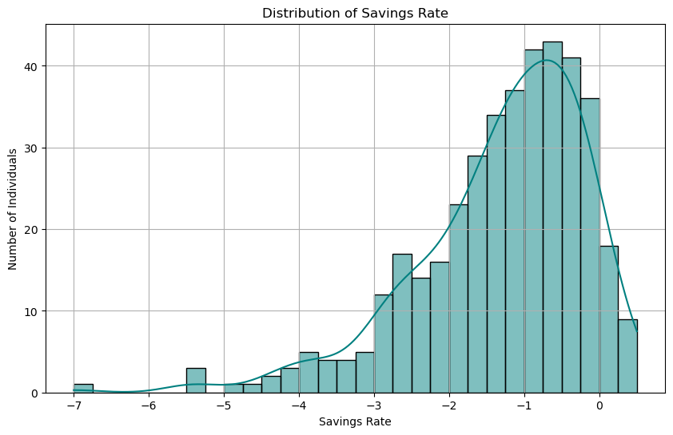

```python
plt.figure(figsize=(10, 6))
sns.histplot(df['Savings_Rate'], kde=True, color='teal', bins=30)
plt.title('Distribution of Savings Rate')
plt.xlabel('Savings Rate')
plt.ylabel('Number of Individuals')
plt.grid(1)
plt.show()
```

Majority Have Negative Savings Rate.

Most individuals in the dataset have a negative savings rate, especially between -2.5 and -0.5

spending is higher than income for many individuals.

Very few individuals have a positive savings rate (above 0), which means only a small portion are saving money. money.

# **Count of Applicants by Gender**

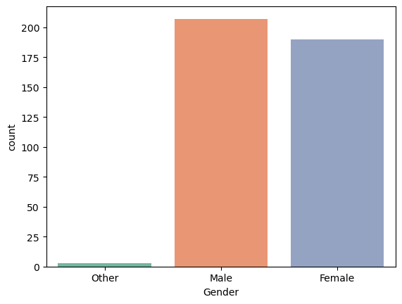

```python
sns.countplot(df,x="Gender",palette="Set2")
```

# Insights

- The male category has the highest count
- The female category follows closely
- The Other category has very few entries

# This pie chart shows how a group of people are divided by their professions.

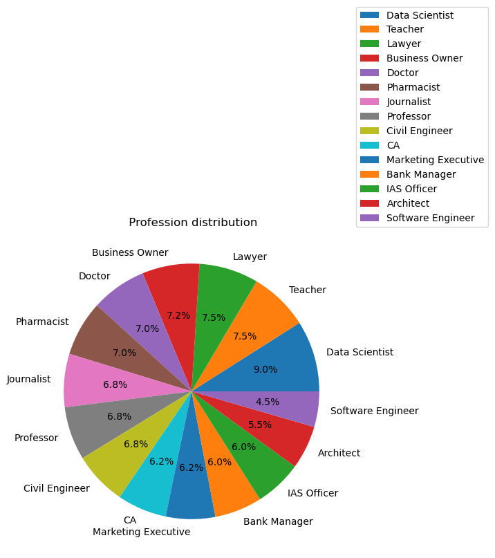

```python
plt.figure(figsize=(6,6))
Profession=df["Profession"].value_counts()
plt.pie(Profession.values,labels=Profession.index,autopct="%1.1f%%")
plt.title(" Profession distribution")
plt.legend(loc="lower left", bbox_to_anchor=(1,1))
```

- This is a pie chart showing the percentage distribution of people by profession in your dataset.
- Each slice of the pie represents a different profession, and its size shows the proportion.

# **Scatter plot of Applicant Income vs Home Loan EMI**

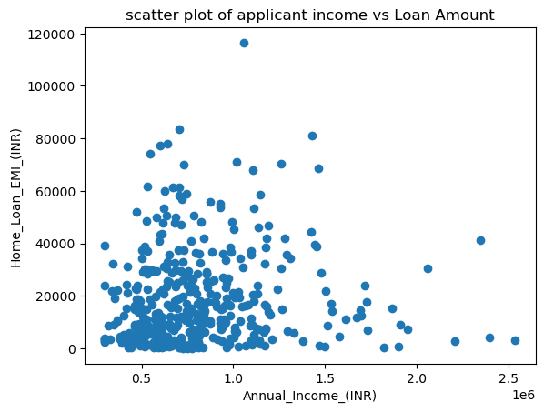

```python
plt.scatter(df["Annual_Income_(INR)"],df["Home_Loan_EMI_(INR)"])
plt.title("scatter plot of applicant income vs Loan Amount")
plt.xlabel("Annual_Income_(INR)")
plt.ylabel("Home_Loan_EMI_(INR)")
plt.show()
```

# Insights

- Most of the data points are concentrated where the annual income is between ₹4 Lakhs and ₹10 Lakhs.
- most applicants are middle-income earners.
- People with high income may still take small loans.
- Banks might limit EMI based on other factors like credit history or liabilities.

# **Monthly Expenses (INR) by Gender and Marital Status**

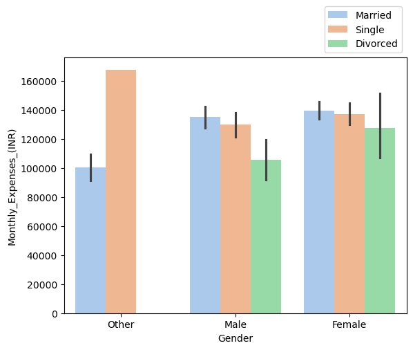

```python
sns.barplot(df,x="Gender",y="Monthly_Expenses_(INR)",hue="Marital_Status",palette="pastel")
plt.legend(loc="lower right",bbox_to_anchor=(1,1))
```

## Among females, married women have the highest expenses, followed by singles and then divorced

## Divorced individuals (across all genders) generally have lower monthly expenses.

## "Other" gender singles have very high monthly expenses compared to others — this is a strong outlier.

# **What is the relationship between total debt and net worth among different genders?**

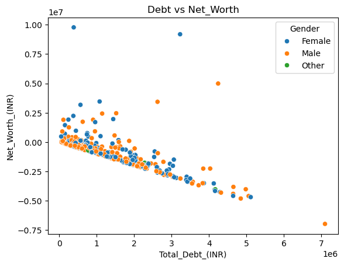

```python
sns.scatterplot(df,x="Total_Debt_(INR)",y="Net_Worth_(INR)",hue="Gender")
plt.title("Debt vs Net_Worth")
plt.show()
```

## Some People Have High Net Worth with Low Debt

## A few people manage money well — they have less debt and high net worth.

## Most People Have Negative Net Worth

## Many dots are below zero, which means many people owe more than they own.

## Both Men and Women Follow Similar Patterns

## No major difference between male and female — both show similar trends.

## Only Few “Other” Gender Data Points

## Very few people in the "Other" category are in this dataset.

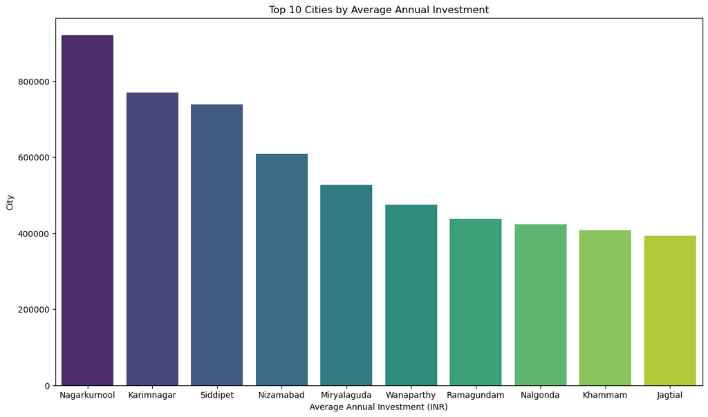

```python
top_investment_cities=df.groupby("City")["Investments_(INR)"].mean().sort_values(ascending=False).head(10)
plt.figure(figsize=(14,8))
sns.barplot(y=top_investment_cities.values, x=top_investment_cities.index,palette="viridis")
plt.title("Top 10 Cities by Average Annual Investment")
plt.xlabel("Average Annual Investment (INR)")
plt.ylabel("City")
plt.show()
```

### → These cities may have better financial literacy, economic growth, or income levels

# **FINANCIAL INSIGHTS**

## 1. Set a Budget

## 2. Cut Unnecessary Expenses

## 3. Pay Off High-interest Debt

## 4. Use Automatic Savings

## 5. Take Advantage of Employer Benefits

## 6. Start an Emergency Fund

## 7. Invest in Your Future

## 8. Avoid Impulse Purchases

## 9. Find Ways to Earn Extra Income

## 10. Use Cash

## 11. Take Advantage of Coupons and Discounts

## 12. Meal Plan

## 13. Shop in Bulk

## 14. Rent Instead of Buy